# Diabetic Retinopathy Prediction

Nikesh Yadav

12/20/2016

Load the libraries

```r
library(imager)
library(EBImage)
library(randomForest)
library(glmnet)
library(e1071)
```

Handy dandy function to extract the grayscale pixel values of resized images

```r
GSvals <- function(eye_Image) {
  im <- load.image(eye_Image)
  gray <- grayscale(im)
  resize.im <- resize(gray, w=100, h=100)
  mat <- matrix(resize.im, nrow=1)
  return(mat)
}
```

How does the diabetic eyes look?

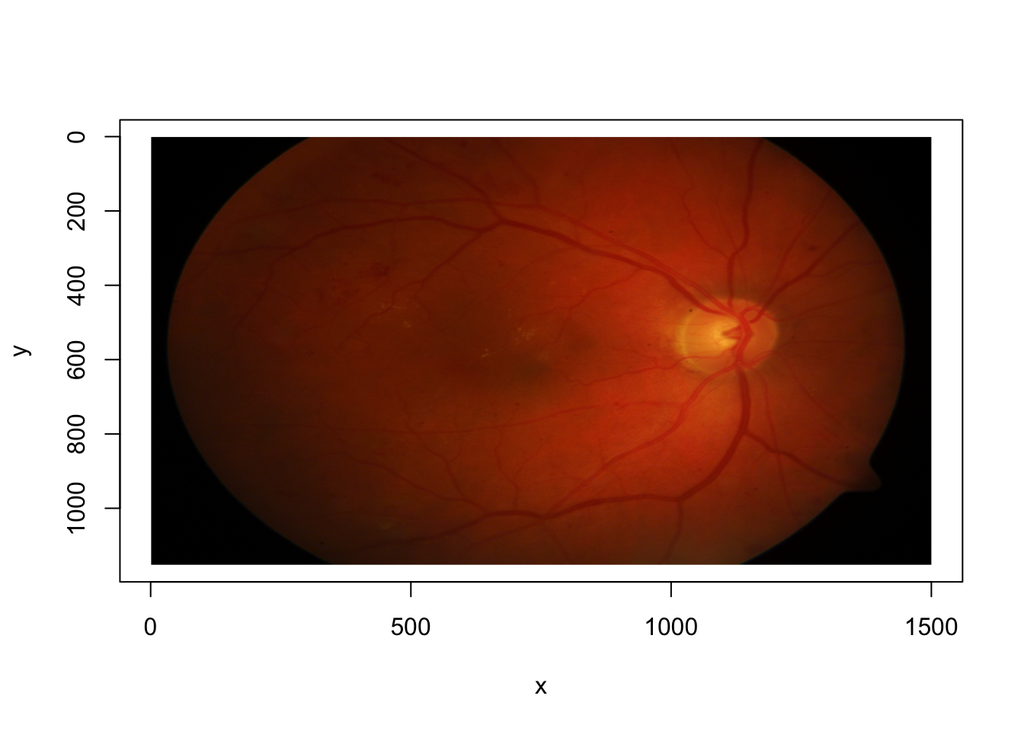

```r
diabetic <- load.image("eyes/dr3.jpg")
plot(diabetic)
```

And the healthy eyes?

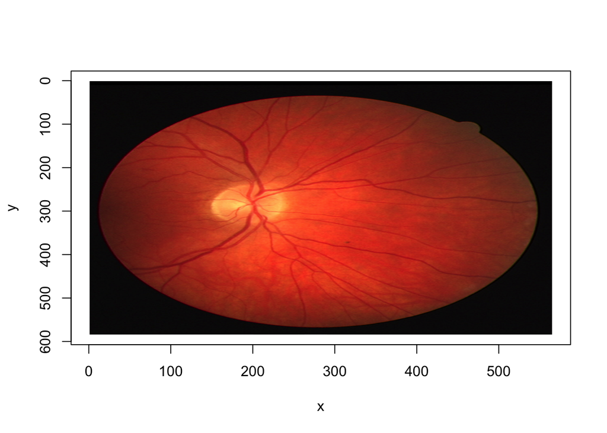

```r
healthy <- load.image("eyes/h15.jpg")
plot(healthy)
```

How the resized grayscale 100 * 100 image look?

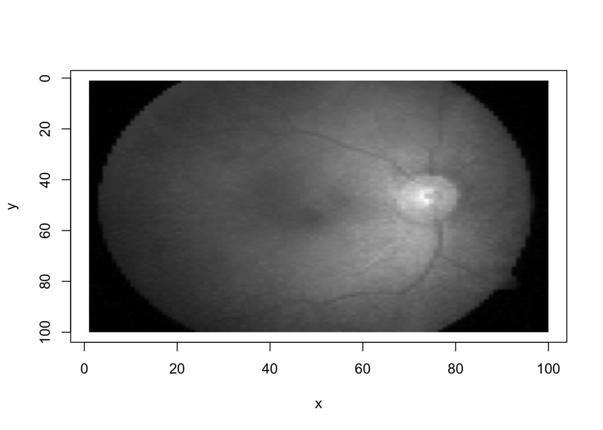

```r
resiz <- resize(diabetic, w=100, h=100)
gr <- grayscale(resiz)
plot(gr)
```

Load pixel values for Diabetic Retinopathy eyes

```r
dr1 <- GSvals("eyes/dr1.jpg")
dr2 <- GSvals("eyes/dr2.jpg")
dr3 <- GSvals("eyes/dr3.jpg")
dr4 <- GSvals("eyes/dr4.jpg")
dr5 <- GSvals("eyes/dr5.jpg")
dr6 <- GSvals("eyes/dr6.jpg")
dr7 <- GSvals("eyes/dr7.jpg")
dr8 <- GSvals("eyes/dr8.jpg")
dr9 <- GSvals("eyes/dr9.jpg")
dr10 <- GSvals("eyes/dr10.jpg")
dr11 <- GSvals("eyes/dr11.jpg")
dr12 <- GSvals("eyes/dr12.jpg")
dr13 <- GSvals("eyes/dr13.jpg")
dr14 <- GSvals("eyes/dr14.jpg")
dr15 <- GSvals("eyes/dr15.jpg")
dr16 <- GSvals("eyes/dr16.jpg")
dr17 <- GSvals("eyes/dr17.jpg")
dr18 <- GSvals("eyes/dr18.jpg")
dr19 <- GSvals("eyes/dr19.jpg")
dr20 <- GSvals("eyes/dr20.jpg")
dr21 <- GSvals("eyes/dr21.jpg")
dr22 <- GSvals("eyes/dr22.jpg")
dr23 <- GSvals("eyes/dr23.jpg")
dr24 <- GSvals("eyes/dr24.jpg")
dr25 <- GSvals("eyes/dr25.jpg")
dr26 <- GSvals("eyes/dr29.jpg")
dr27 <- GSvals("eyes/dr27.jpg")
dr28 <- GSvals("eyes/dr28.jpg")
dr29 <- GSvals("eyes/dr29.jpg")
dr30 <- GSvals("eyes/dr30.jpg")
dr31 <- GSvals("eyes/dr31.jpg")
dr32 <- GSvals("eyes/dr32.jpg")
dr33 <- GSvals("eyes/dr33.jpg")
dr34 <- GSvals("eyes/dr34.jpg")
dr35 <- GSvals("eyes/dr35.jpg")
dr36 <- GSvals("eyes/dr36.jpg")
dr37 <- GSvals("eyes/dr37.jpg")
dr38 <- GSvals("eyes/dr38.jpg")
dr39 <- GSvals("eyes/dr39.jpg")
dr40 <- GSvals("eyes/dr40.jpg")
dr41 <- GSvals("eyes/dr41.jpg")
dr42 <- GSvals("eyes/dr42.jpg")
dr43 <- GSvals("eyes/dr43.jpg")
dr44 <- GSvals("eyes/dr44.jpg")
dr45 <- GSvals("eyes/dr45.jpg")
dr46 <- GSvals("eyes/dr46.jpg")
dr47 <- GSvals("eyes/dr47.jpg")
dr48 <- GSvals("eyes/dr48.jpg")
dr49 <- GSvals("eyes/dr49.jpg")
dr50 <- GSvals("eyes/dr50.jpg")
dr51 <- GSvals("eyes/dr51.jpg")
dr52 <- GSvals("eyes/dr52.jpg")
dr53 <- GSvals("eyes/dr53.jpg")
dr54 <- GSvals("eyes/dr54.jpg")
dr55 <- GSvals("eyes/dr55.jpg")
dr56 <- GSvals("eyes/dr56.jpg")
dr57 <- GSvals("eyes/dr57.jpg")
dr58 <- GSvals("eyes/dr58.jpg")
dr59 <- GSvals("eyes/dr59.jpg")
dr60 <- GSvals("eyes/dr60.jpg")
dr61 <- GSvals("eyes/dr61.jpg")
dr62 <- GSvals("eyes/dr62.jpg")
dr63 <- GSvals("eyes/dr63.jpg")
dr64 <- GSvals("eyes/dr64.jpg")
dr65 <- GSvals("eyes/dr65.jpg")
dr66 <- GSvals("eyes/dr66.jpg")
dr67 <- GSvals("eyes/dr67.jpg")
dr68 <- GSvals("eyes/dr68.jpg")
dr69 <- GSvals("eyes/dr69.jpg")
dr70 <- GSvals("eyes/dr70.jpg")
dr71 <- GSvals("eyes/dr71.jpg")
dr72 <- GSvals("eyes/dr72.jpg")
dr73 <- GSvals("eyes/dr73.jpg")
dr74 <- GSvals("eyes/dr74.jpg")
dr75 <- GSvals("eyes/dr75.jpg")
dr76 <- GSvals("eyes/dr76.jpg")
dr77 <- GSvals("eyes/dr77.jpg")
dr78 <- GSvals("eyes/dr78.jpg")
dr79 <- GSvals("eyes/dr79.jpg")
dr80<- GSvals("eyes/dr80.jpg")
dr81 <- GSvals("eyes/dr81.jpg")
dr82 <- GSvals("eyes/dr82.jpg")
dr83 <- GSvals("eyes/dr83.jpg")
dr84 <- GSvals("eyes/dr84.jpg")
dr85 <- GSvals("eyes/dr85.jpg")
dr86 <- GSvals("eyes/dr86.jpg")
dr87 <- GSvals("eyes/dr87.jpg")
dr88 <- GSvals("eyes/dr88.jpg")
dr89 <- GSvals("eyes/dr89.jpg")
```

Load the pixel values for healthy eyes

```r
h1 <- GSvals("eyes/h1.jpg")
h2 <- GSvals("eyes/h2.jpg")
h3 <- GSvals("eyes/h3.jpg")
h4 <- GSvals("eyes/h4.jpg")
h5 <- GSvals("eyes/h5.jpg")
h6 <- GSvals("eyes/h6.jpg")
h7 <- GSvals("eyes/h7.jpg")
h8 <- GSvals("eyes/h8.jpg")
h9 <- GSvals("eyes/h9.jpg")
h10 <- GSvals("eyes/h10.jpg")
h11 <- GSvals("eyes/h11.jpg")
h12 <- GSvals("eyes/h12.jpg")
h13 <- GSvals("eyes/h13.jpg")
h14 <- GSvals("eyes/h14.jpg")
h15 <- GSvals("eyes/h15.jpg")
h16 <- GSvals("eyes/h16.jpg")
h17 <- GSvals("eyes/h17.jpg")
h18 <- GSvals("eyes/h18.jpg")
h19 <- GSvals("eyes/h19.jpg")
h20 <- GSvals("eyes/h20.jpg")
h21 <- GSvals("eyes/h21.jpg")
h22 <- GSvals("eyes/h22.jpg")
h23 <- GSvals("eyes/h23.jpg")
h24 <- GSvals("eyes/h24.jpg")
h25 <- GSvals("eyes/h25.jpg")
h26 <- GSvals("eyes/h26.jpg")
h27 <- GSvals("eyes/h27.jpg")
h28 <- GSvals("eyes/h28.jpg")
h29 <- GSvals("eyes/h29.jpg")
h30 <- GSvals("eyes/h30.jpg")
h31 <- GSvals("eyes/h31.jpg")
h32 <- GSvals("eyes/h32.jpg")
h33 <- GSvals("eyes/h33.jpg")
h34 <- GSvals("eyes/h34.jpg")
h35 <- GSvals("eyes/h35.jpg")
h36 <- GSvals("eyes/h36.jpg")
h37 <- GSvals("eyes/h37.jpg")
h38 <- GSvals("eyes/h38.jpg")
h39 <- GSvals("eyes/h39.jpg")
h40 <- GSvals("eyes/h40.jpg")
```

Create a data frame eye.df where each row consists of pixel values of each image and a response variable. Assign the response variable as 1 for diabetic retinopathy and 0 for healthy eyes

```r
type = c(rep(1,89), rep(0,40))
eye.df <- data.frame(rbind(
  dr1,dr2,dr3,dr4,dr5,dr6,dr7,dr8,dr9,dr10,dr11,dr12,dr13,dr14,dr15,dr16,dr17,dr18,
  dr19,dr20,dr21,dr22,dr23,dr24,dr25,dr26,dr27,dr28,dr29,dr30,dr31,dr32,dr33,dr34,
  dr35,dr36,dr37,dr38,dr39,dr40,dr41,dr42,dr43,dr44,dr45,dr46,dr47,dr48,dr49,dr50,
  dr51,dr52,dr53,dr54,dr55,dr56,dr57,dr58,dr59,dr60,dr61,dr62,dr63,dr64,dr65,dr66,
  dr67,dr68,dr69,dr70,dr71,dr72,dr73,dr74,dr75,dr76,dr77,dr78,dr79,dr80,dr81,dr82,
  dr83,dr84,dr85,dr86,dr87,dr88,dr89,h1,h2,h3,h4,h5,h6,h7,h8,h9,h10,h11,h12,h13,h14,
  h15,h16,h17,h18,h19,h20,h21,h22,h23,h24,h25,h26,h27,h28,h29,h30,h31,h32,h33,h34,
  h35,h36,h37,h38,h39,h40),

  resp=type)
```

Take principal components of newly created eye.df that has 10,000 predictors

```r
eye.df_noresp <- eye.df[,-ncol(eye.df)]
pca.eye <- prcomp(eye.df_noresp, scale=T)
summary(pca.eye)
```

```
## Importance of components:
##                            PC1      PC2     PC3     PC4     PC5     PC6
## Standard deviation     97.1905 11.73559 9.12635 8.34395 6.38795 5.85687
## Proportion of Variance  0.9446  0.01377 0.00833 0.00696 0.00408 0.00343
## Cumulative Proportion   0.9446  0.95837 0.96670 0.97366 0.97774 0.98117
##                            PC7    PC8     PC9    PC10    PC11   PC12
## Standard deviation     4.93618 4.4758 3.96799 3.84758 3.24299 2.9992
## Proportion of Variance 0.00244 0.0020 0.00157 0.00148 0.00105 0.0009
## Cumulative Proportion  0.98361 0.9856 0.98719 0.98867 0.98972 0.9906
##                           PC13   PC14   PC15    PC16    PC17    PC18
## Standard deviation     2.72822 2.6465 2.4494 2.32192 2.19543 2.12715
## Proportion of Variance 0.00074 0.0007 0.0006 0.00054 0.00048 0.00045
## Cumulative Proportion  0.99136 0.9921 0.9927 0.99320 0.99368 0.99414
##                           PC19    PC20    PC21    PC22    PC23    PC24
## Standard deviation     2.07865 1.97328 1.94673 1.85214 1.81237 1.77875
## Proportion of Variance 0.00043 0.00039 0.00038 0.00034 0.00033 0.00032
## Cumulative Proportion  0.99457 0.99496 0.99534 0.99568 0.99601 0.99633
##                           PC25    PC26    PC27    PC28    PC29    PC30
## Standard deviation     1.71720 1.68291 1.65017 1.54815 1.51761 1.51305
## Proportion of Variance 0.00029 0.00028 0.00027 0.00024 0.00023 0.00023
## Cumulative Proportion  0.99662 0.99690 0.99718 0.99742 0.99765 0.99788
##                           PC31    PC32    PC33   PC34    PC35    PC36
## Standard deviation     1.49183 1.47626 1.44789 1.4097 1.39303 1.35469
## Proportion of Variance 0.00022 0.00022 0.00021 0.0002 0.00019 0.00018
## Cumulative Proportion  0.99810 0.99832 0.99853 0.9987 0.99892 0.99910
##                           PC37    PC38    PC39    PC40    PC41    PC42
## Standard deviation     1.32206 1.30399 1.26240 1.21775 1.12638 0.74648
## Proportion of Variance 0.00017 0.00017 0.00016 0.00015 0.00013 0.00006
## Cumulative Proportion  0.99928 0.99945 0.99961 0.99975 0.99988 0.99994
##                           PC43    PC44    PC45    PC46   PC47   PC48
## Standard deviation     0.44986 0.31214 0.24382 0.22580 0.1928 0.1679
## Proportion of Variance 0.00002 0.00001 0.00001 0.00001 0.0000 0.0000
## Cumulative Proportion  0.99996 0.99997 0.99997 0.99998 1.0000 1.0000
##                          PC49   PC50   PC51   PC52    PC53    PC54    PC55
## Standard deviation     0.1357 0.1129 0.1083 0.0965 0.08721 0.08154 0.07501
## Proportion of Variance 0.0000 0.0000 0.0000 0.0000 0.00000 0.00000 0.00000
## Cumulative Proportion  1.0000 1.0000 1.0000 1.0000 0.99999 0.99999 0.99999
##                           PC56   PC57    PC58    PC59    PC60    PC61
## Standard deviation     0.07232 0.0712 0.06888 0.06455 0.06391 0.06145
## Proportion of Variance 0.00000 0.0000 0.00000 0.00000 0.00000 0.00000
```

[output cut: 34 more lines]

```
## Standard deviation     0.01384 0.0131 0.01291 0.0127 0.01202 0.01193
## Proportion of Variance 0.00000 0.0000 0.00000 0.0000 0.00000 0.00000
## Cumulative Proportion  1.00000 1.0000 1.00000 1.0000 1.00000 1.00000
##                          PC116   PC117   PC118   PC119  PC120   PC121
## Standard deviation     0.01142 0.01127 0.01122 0.01083 0.0108 0.01053
## Proportion of Variance 0.00000 0.00000 0.00000 0.00000 0.0000 0.00000
## Cumulative Proportion  1.00000 1.00000 1.00000 1.00000 1.0000 1.00000
##                          PC122    PC123    PC124    PC125    PC126
## Standard deviation     0.01021 0.009781 0.009474 0.009307 0.008779
## Proportion of Variance 0.00000 0.000000 0.000000 0.000000 0.000000
## Cumulative Proportion  1.00000 1.000000 1.000000 1.000000 1.000000
##                           PC127     PC128     PC129
## Standard deviation     0.007928 1.468e-14 9.709e-15
## Proportion of Variance 0.000000 0.000e+00 0.000e+00
## Cumulative Proportion  1.000000 1.000e+00 1.000e+00
```

```r
#The rotation matrix
rots <- pca.eye$rotation
dim(rots)
```

```
## [1] 10000   129
```

```r
eye.mat <- as.matrix(eye.df_noresp[,1:ncol(eye.df_noresp)])
dim(eye.mat)
```

```
## [1]   129 10000
```

```r
#Principal components
pcs <- eye.mat %*% rots
dim(pcs)
```

```
## [1] 129 129
```

```r
#Data frame with principal components as predictors and the corresponding response variable
prcomp.df <- data.frame(pcs, resp = type)
```

Try RandomForest on the principal components

```r
nr <- nrow(prcomp.df)
test <- sample(1:nr, nr/2, rep=F)
train <- setdiff(1:nr, test)

test.df <- prcomp.df[test,]
train.df <- prcomp.df[train,]

rf <- randomForest(as.factor(resp)~., data=train.df, ntree=500)
pred <- predict(rf, newdata = test.df)
pred
```

```
##  50  66  99  34  63  65   1 128  89  98 112  20   2 108 127  62  31  54
##   1   1   0   1   1   1   1   0   1   0   0   1   1   0   0   1   1   1
##  21  93  64  57  35 120 104   3   6 122  53 115  84 123  30  28 129  12
##   1   0   1   1   1   0   0   1   1   0   1   0   1   0   1   1   0   1
##  46  14   8  77  81  68  80  91  67  39   9  37  83 101  33  73 103  87
##   1   1   1   1   1   1   1   0   1   1   1   1   1   0   1   1   0   1
##  27  44  60  24   7 100 118  79  19  36
##   1   1   1   1   1   0   0   1   1   1
## Levels: 0 1
```

```r
test.df$resp
```

```
##  [1] 1 1 0 1 1 1 1 0 1 0 0 1 1 0 0 1 1 1 1 0 1 1 1 0 0 1 1 0 1 0 1 0 1 1 0
## [36] 1 1 1 1 1 1 1 1 0 1 1 1 1 1 0 1 1 0 1 1 1 1 1 1 0 0 1 1 1
```

```r
mean(pred != test.df$resp)
```

```
## [1] 0
```

Now let’s try LASSO on 10,000 predictors with lambda from 10^-2 - 10^2 divided into 100 sequences

```r
x <- data.matrix(eye.df[,-ncol(eye.df)])
y <- data.matrix(eye.df[,ncol(eye.df)])
test <- sample(1:nr, nr/2, rep=F)
train <- setdiff(1:nr, test)
x.train <- x[train,]
y.train <- y[train,]
x.test <- x[test,]
y.test <- y[test,]

cv.lasso <- cv.glmnet(x.train, y.train, alpha = 1, family="binomial")
cv.lasso$lambda.min
```

```
## [1] 0.005000683
```

```r
cv.lasso$lambda.1se
```

```
## [1] 0.005238794
```

```r
error <- rep(0,100)
i <- 1
for (lamb in 10^seq(-2,2, length = 100)) {
  test <- sample(1:nr, nr/2, rep=F)
  train <- setdiff(1:nr, test)
  x.train <- x[train,]
  y.train <- y[train,]
  x.test <- x[test,]
  y.test <- y[test,]
  fit.lasso <- glmnet(x.train, y.train, alpha = 1, lambda = lamb, family = "binomial")
  pred.lasso <- predict(fit.lasso, newx = x.test, type="class")
  error[i] = mean(as.numeric(pred.lasso) != y.test)
  i <- i+1
}
print(error)
```

```
##   [1] 0.000000 0.000000 0.000000 0.000000 0.000000 0.000000 0.000000
##   [8] 0.000000 0.000000 0.000000 0.000000 0.000000 0.000000 0.000000
##  [15] 0.000000 0.000000 0.000000 0.000000 0.000000 0.000000 0.000000
##  [22] 0.000000 0.000000 0.000000 0.000000 0.000000 0.000000 0.000000
##  [29] 0.000000 0.000000 0.000000 0.000000 0.000000 0.000000 0.000000
##  [36] 0.015625 0.000000 0.156250 0.250000 0.296875 0.375000 0.359375
##  [43] 0.265625 0.234375 0.265625 0.203125 0.296875 0.296875 0.312500
##  [50] 0.328125 0.343750 0.328125 0.281250 0.328125 0.328125 0.406250
##  [57] 0.296875 0.312500 0.343750 0.296875 0.265625 0.296875 0.265625
##  [64] 0.265625 0.265625 0.343750 0.359375 0.375000 0.234375 0.296875
##  [71] 0.312500 0.250000 0.359375 0.375000 0.312500 0.312500 0.250000
##  [78] 0.328125 0.375000 0.296875 0.296875 0.265625 0.343750 0.328125
##  [85] 0.203125 0.234375 0.359375 0.359375 0.328125 0.265625 0.234375
##  [92] 0.359375 0.343750 0.328125 0.250000 0.359375 0.375000 0.296875
##  [99] 0.265625 0.343750
```

```r
min(error)
```

```
## [1] 0
```

How does it look for lambda values in between cv.lasso$lambda.min and cv.lasso$lambda.1se

```r
i <- 1
for (lamb in seq(cv.lasso$lambda.min, cv.lasso$lambda.1se, length=100)) {
  test <- sample(1:nr, nr/2, rep=F)
  train <- setdiff(1:nr, test)
  x.train <- x[train,]
  y.train <- y[train,]
  x.test <- x[test,]
  y.test <- y[test,]
  fit.lasso <- glmnet(x.train, y.train, alpha = 1, lambda = lamb, family = "binomial")
  pred.lasso <- predict(fit.lasso, newx = x.test, type="class")
  error[i] = mean(as.numeric(pred.lasso) != y.test)
  i <- i+1
}
print(error)
```

```
##   [1] 0 0 0 0 0 0 0 0 0 0 0 0 0 0 0 0 0 0 0 0 0 0 0 0 0 0 0 0 0 0 0 0 0 0 0
##  [36] 0 0 0 0 0 0 0 0 0 0 0 0 0 0 0 0 0 0 0 0 0 0 0 0 0 0 0 0 0 0 0 0 0 0 0
##  [71] 0 0 0 0 0 0 0 0 0 0 0 0 0 0 0 0 0 0 0 0 0 0 0 0 0 0 0 0 0 0
```

```r
min(error)
```

```
## [1] 0
```

How does the LASSO model look?

```r
fit.lasso <- glmnet(x.train, y.train, alpha=1, lambda = cv.lasso$lambda.min, family="binomial")
coef(fit.lasso)
```

```
## 10001 x 1 sparse Matrix of class "dgCMatrix"
##                        s0
## (Intercept)   5.839058116
## X1            .
## X2            .
## X3            .
## X4            .
## X5            .
## X6            .
## X7            .
## X8            .
## X9            .
## X10           .
## X11           .
## X12           .
## X13           .
## X14           .
## X15           .
## X16           .
## X17           .
## X18           .
## X19           .
## X20           .
## X21           .
## X22           .
## X23           .
## X24           .
## X25           .
## X26           .
## X27           .
## X28           .
## X29           .
## X30           .
## X31           .
## X32           .
## X33           .
## X34           .
## X35           .
## X36           .
## X37           .
```

[output cut: 9948 more lines]

```
## X9986         .
## X9987         .
## X9988         .
## X9989         .
## X9990        -0.005605482
## X9991         .
## X9992         .
## X9993         .
## X9994         .
## X9995         .
## X9996         .
## X9997         .
## X9998         .
## X9999         .
## X10000        .
```

Lasso on Principal Components

```r
x <- data.matrix(prcomp.df[,-ncol(prcomp.df)])
y <- data.matrix(prcomp.df[,ncol(prcomp.df)])
test <- sample(1:nr, nr/2, rep=F)
train <- setdiff(1:nr, test)
x.train <- x[train,]
y.train <- y[train,]
x.test <- x[test,]
y.test <- y[test,]

cv.lasso <- cv.glmnet(x.train, y.train, alpha = 1, family="binomial")
cv.lasso$lambda.min
```

```
## [1] 0.004876199
```

```r
cv.lasso$lambda.1se
```

```
## [1] 0.01712127
```

```r
error <- rep(0,100)
i <- 1
for (lamb in seq(cv.lasso$lambda.min, cv.lasso$lambda.1se, length=100)) {
  test <- sample(1:nr, nr/2, rep=F)
  train <- setdiff(1:nr, test)
  x.train <- x[train,]
  y.train <- y[train,]
  x.test <- x[test,]
  y.test <- y[test,]
  fit.lasso <- glmnet(x.train, y.train, alpha = 1, lambda = lamb, family = "binomial")
  pred.lasso <- predict(fit.lasso, newx = x.test, type="class")
  error[i] = mean(as.numeric(pred.lasso) != y.test)
  i <- i+1
}
error
```

```
##   [1] 0.000000 0.000000 0.000000 0.000000 0.000000 0.000000 0.000000
##   [8] 0.000000 0.000000 0.000000 0.000000 0.000000 0.000000 0.000000
##  [15] 0.000000 0.000000 0.000000 0.000000 0.000000 0.000000 0.000000
##  [22] 0.000000 0.015625 0.000000 0.000000 0.000000 0.000000 0.000000
##  [29] 0.015625 0.000000 0.000000 0.000000 0.000000 0.000000 0.000000
##  [36] 0.000000 0.000000 0.000000 0.000000 0.000000 0.000000 0.000000
##  [43] 0.015625 0.000000 0.000000 0.000000 0.000000 0.000000 0.015625
##  [50] 0.000000 0.000000 0.000000 0.000000 0.000000 0.000000 0.000000
##  [57] 0.000000 0.000000 0.000000 0.000000 0.000000 0.000000 0.000000
##  [64] 0.000000 0.000000 0.000000 0.000000 0.000000 0.000000 0.000000
##  [71] 0.015625 0.000000 0.000000 0.000000 0.015625 0.000000 0.000000
##  [78] 0.000000 0.000000 0.000000 0.000000 0.000000 0.015625 0.015625
##  [85] 0.000000 0.000000 0.000000 0.000000 0.000000 0.000000 0.000000
##  [92] 0.000000 0.000000 0.000000 0.000000 0.015625 0.000000 0.000000
##  [99] 0.015625 0.000000
```

```r
min(error)
```

```
## [1] 0
```

Ridge Regression on Principal Components

```r
x <- data.matrix(prcomp.df[,-ncol(prcomp.df)])
y <- data.matrix(prcomp.df[,ncol(prcomp.df)])
test <- sample(1:nr, nr/2, rep=F)
train <- setdiff(1:nr, test)
x.train <- x[train,]
y.train <- y[train,]
x.test <- x[test,]
y.test <- y[test,]

cv.ridge <- cv.glmnet(x.train, y.train, alpha = 0, family="binomial")
cv.ridge$lambda.min
```

```
## [1] 4.757848
```

```r
cv.ridge$lambda.1se
```

```
## [1] 6.003723
```

```r
error <- rep(0,100)
i <- 1
for (lamb in seq(cv.ridge$lambda.min,cv.ridge$lambda.1se,length = 100)) {
  test <- sample(1:nr, nr/2, rep=F)
  train <- setdiff(1:nr, test)
  x.train <- x[train,]
  y.train <- y[train,]
  x.test <- x[test,]
  y.test <- y[test,]
  fit.ridge <- glmnet(x.train, y.train, alpha = 0, lambda = lamb, family = "binomial")
  pred.ridge <- predict(fit.ridge, newx = x.test, type="class")
  error[i] = mean(as.numeric(pred.ridge) != y.test)
  i <- i+1
}
error
```

```
##   [1] 0 0 0 0 0 0 0 0 0 0 0 0 0 0 0 0 0 0 0 0 0 0 0 0 0 0 0 0 0 0 0 0 0 0 0
##  [36] 0 0 0 0 0 0 0 0 0 0 0 0 0 0 0 0 0 0 0 0 0 0 0 0 0 0 0 0 0 0 0 0 0 0 0
##  [71] 0 0 0 0 0 0 0 0 0 0 0 0 0 0 0 0 0 0 0 0 0 0 0 0 0 0 0 0 0 0
```

```r
min(error)
```

```
## [1] 0
```

SVM on Principal Components with Radial kernel

```r
test <- sample(1:nr, nr/2, rep=F)
train <- setdiff(1:nr, test)
test.df <- prcomp.df[test,]
train.df <- prcomp.df[train,]

tune.svm <-
  tune(svm,as.factor(resp) ~.,
       data=train.df,
       kernel="radial",
       scale=F,
       ranges=list(cost=10^seq(-5,5,length=50), gamma=10^seq(-5,5)),
       ##use cross=3 to speed up
       tunecontrol=tune.control(cross=3))

C <- tune.svm$best.parameters[1]
G <- tune.svm$best.parameters[2]
C
```

```
##        cost
## 29 5.179475
```

```r
G
```

```
##    gamma
## 29 1e-05
```

```r
svmfit <- svm(as.factor(resp) ~.,
              data = train.df,
              kernel = "radial",
              cost = C,
              gamma = G,
              scale = F)
pred.svm <- predict(svmfit, newdata = test.df)
pred.svm
```

```
##  87  83 113  38  48  11 126   3 120  70 101  71  89  94  16  42 123  78
##   1   1   0   1   1   1   0   1   0   1   0   1   1   0   1   1   0   1
## 102  57   9 124   4   6  32  55 107  15  72   2  13 122   1  45  74  28
##   0   1   1   0   1   1   1   1   0   1   1   1   1   0   1   1   1   1
##  97 105 116  58  52  93  18  10 111  51  75  29   5  79 115  85  33  59
##   0   0   0   1   1   0   1   1   0   1   1   1   1   1   0   1   1   1
##  63  41  99  95   7  69 103 106  40  36
##   1   1   0   0   1   1   0   0   1   1
## Levels: 0 1
```

```r
test.df$resp
```

```
##  [1] 1 1 0 1 1 1 0 1 0 1 0 1 1 0 1 1 0 1 0 1 1 0 1 1 1 1 0 1 1 1 1 0 1 1 1
## [36] 1 0 0 0 1 1 0 1 1 0 1 1 1 1 1 0 1 1 1 1 1 0 0 1 1 0 0 1 1
```

```r
mean(pred.svm != test.df$resp)
```

```
## [1] 0
```

SVM with Polynomial kernel

```r
test <- sample(1:nr, nr/2, rep=F)
train <- setdiff(1:nr, test)
test.df <- prcomp.df[test,]
train.df <- prcomp.df[train,]

tune.svm <-
  tune(svm,as.factor(resp) ~.,
       data=train.df,
       kernel="polynomial",
       scale=F,
       ranges=list(cost=10^seq(-10,10,length=50), d=seq(1,10)),
       ##use cross=3 to speed up
       tunecontrol=tune.control(cross=3))

C <- tune.svm$best.parameters[1]
D <- tune.svm$best.parameters[2]
C
```

```
##          cost
## 21 0.01456348
```

```r
D
```

```
##    d
## 21 1
```

```r
svmfit <- svm(as.factor(resp) ~.,
              data = train.df,
              kernel = "polynomial",
              cost = C,
              degree = D,
              scale = F)
pred.svm <- predict(svmfit, newdata = test.df)
pred.svm
```

```
##  89   4  98  40  51 118  63 105  37  41  62  79  64 129  57  19  15 110
##   1   1   0   1   1   0   1   0   1   1   1   1   1   0   1   1   1   0
## 104  29 115  81  99  93  47 100   8 124 113  74 107  13 126  75 114  92
##   0   1   0   1   0   0   1   0   1   0   0   1   0   1   0   1   0   0
## 116 119  59  60  97  11  56 106  96  66  82  95 111 121  49  10 109  21
##   0   0   1   1   0   1   1   0   0   1   1   0   0   0   1   1   0   1
##  54   9  65  72 108 117  78  87  35  80
##   1   1   1   1   0   0   1   1   1   1
## Levels: 0 1
```

```r
test.df$resp
```

```
##  [1] 1 1 0 1 1 0 1 0 1 1 1 1 1 0 1 1 1 0 0 1 0 1 0 0 1 0 1 0 0 1 0 1 0 1 0
## [36] 0 0 0 1 1 0 1 1 0 0 1 1 0 0 0 1 1 0 1 1 1 1 1 0 0 1 1 1 1
```

```r
mean(pred.svm != test.df$resp)
```

```
## [1] 0
```

# Now let’s resize the images to 10 * 10 !!

How will the image look when resize to 10 * 10?

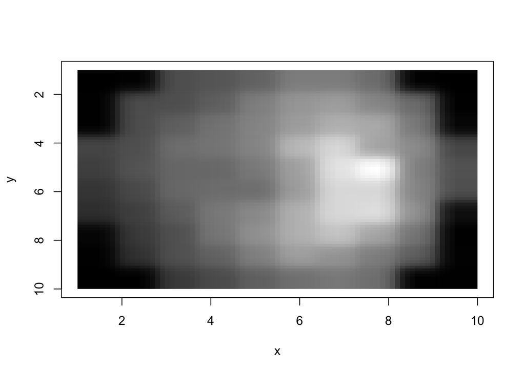

```r
resiz <- resize(diabetic, w=10, h=10)
gr <- grayscale(resiz)
plot(gr)
```

Do same things done above

```r
GSvals <- function(eye_Image) {
  im <- load.image(eye_Image)
  gray <- grayscale(im)
  resize.im <- resize(gray, w=10, h=10)
  mat <- matrix(resize.im, nrow=1)
  return(mat)
}

#Diabetic Retinopathy
dr1 <- GSvals("eyes/dr1.jpg")
dr2 <- GSvals("eyes/dr2.jpg")
dr3 <- GSvals("eyes/dr3.jpg")
dr4 <- GSvals("eyes/dr4.jpg")
dr5 <- GSvals("eyes/dr5.jpg")
dr6 <- GSvals("eyes/dr6.jpg")
dr7 <- GSvals("eyes/dr7.jpg")
dr8 <- GSvals("eyes/dr8.jpg")
dr9 <- GSvals("eyes/dr9.jpg")
dr10 <- GSvals("eyes/dr10.jpg")
dr11 <- GSvals("eyes/dr11.jpg")
dr12 <- GSvals("eyes/dr12.jpg")
dr13 <- GSvals("eyes/dr13.jpg")
dr14 <- GSvals("eyes/dr14.jpg")
dr15 <- GSvals("eyes/dr15.jpg")
dr16 <- GSvals("eyes/dr16.jpg")
dr17 <- GSvals("eyes/dr17.jpg")
dr18 <- GSvals("eyes/dr18.jpg")
dr19 <- GSvals("eyes/dr19.jpg")
dr20 <- GSvals("eyes/dr20.jpg")
dr21 <- GSvals("eyes/dr21.jpg")
dr22 <- GSvals("eyes/dr22.jpg")
dr23 <- GSvals("eyes/dr23.jpg")
dr24 <- GSvals("eyes/dr24.jpg")
dr25 <- GSvals("eyes/dr25.jpg")
dr26 <- GSvals("eyes/dr29.jpg")
dr27 <- GSvals("eyes/dr27.jpg")
dr28 <- GSvals("eyes/dr28.jpg")
dr29 <- GSvals("eyes/dr29.jpg")
dr30 <- GSvals("eyes/dr30.jpg")
dr31 <- GSvals("eyes/dr31.jpg")
dr32 <- GSvals("eyes/dr32.jpg")
dr33 <- GSvals("eyes/dr33.jpg")
dr34 <- GSvals("eyes/dr34.jpg")
dr35 <- GSvals("eyes/dr35.jpg")
dr36 <- GSvals("eyes/dr36.jpg")
dr37 <- GSvals("eyes/dr37.jpg")
dr38 <- GSvals("eyes/dr38.jpg")
dr39 <- GSvals("eyes/dr39.jpg")
dr40 <- GSvals("eyes/dr40.jpg")
dr41 <- GSvals("eyes/dr41.jpg")
dr42 <- GSvals("eyes/dr42.jpg")
dr43 <- GSvals("eyes/dr43.jpg")
dr44 <- GSvals("eyes/dr44.jpg")
dr45 <- GSvals("eyes/dr45.jpg")
dr46 <- GSvals("eyes/dr46.jpg")
dr47 <- GSvals("eyes/dr47.jpg")
dr48 <- GSvals("eyes/dr48.jpg")
dr49 <- GSvals("eyes/dr49.jpg")
dr50 <- GSvals("eyes/dr50.jpg")
dr51 <- GSvals("eyes/dr51.jpg")
dr52 <- GSvals("eyes/dr52.jpg")
dr53 <- GSvals("eyes/dr53.jpg")
dr54 <- GSvals("eyes/dr54.jpg")
dr55 <- GSvals("eyes/dr55.jpg")
dr56 <- GSvals("eyes/dr56.jpg")
dr57 <- GSvals("eyes/dr57.jpg")
dr58 <- GSvals("eyes/dr58.jpg")
dr59 <- GSvals("eyes/dr59.jpg")
dr60 <- GSvals("eyes/dr60.jpg")
dr61 <- GSvals("eyes/dr61.jpg")
dr62 <- GSvals("eyes/dr62.jpg")
dr63 <- GSvals("eyes/dr63.jpg")
dr64 <- GSvals("eyes/dr64.jpg")
dr65 <- GSvals("eyes/dr65.jpg")
dr66 <- GSvals("eyes/dr66.jpg")
dr67 <- GSvals("eyes/dr67.jpg")
dr68 <- GSvals("eyes/dr68.jpg")
dr69 <- GSvals("eyes/dr69.jpg")
dr70 <- GSvals("eyes/dr70.jpg")
dr71 <- GSvals("eyes/dr71.jpg")
dr72 <- GSvals("eyes/dr72.jpg")
dr73 <- GSvals("eyes/dr73.jpg")
dr74 <- GSvals("eyes/dr74.jpg")
dr75 <- GSvals("eyes/dr75.jpg")
dr76 <- GSvals("eyes/dr76.jpg")
dr77 <- GSvals("eyes/dr77.jpg")
dr78 <- GSvals("eyes/dr78.jpg")
dr79 <- GSvals("eyes/dr79.jpg")
dr80<- GSvals("eyes/dr80.jpg")
dr81 <- GSvals("eyes/dr81.jpg")
dr82 <- GSvals("eyes/dr82.jpg")
dr83 <- GSvals("eyes/dr83.jpg")
dr84 <- GSvals("eyes/dr84.jpg")
dr85 <- GSvals("eyes/dr85.jpg")
dr86 <- GSvals("eyes/dr86.jpg")
dr87 <- GSvals("eyes/dr87.jpg")
dr88 <- GSvals("eyes/dr88.jpg")
dr89 <- GSvals("eyes/dr89.jpg")


#Healthy Eyes
h1 <- GSvals("eyes/h1.jpg")
h2 <- GSvals("eyes/h2.jpg")
h3 <- GSvals("eyes/h3.jpg")
h4 <- GSvals("eyes/h4.jpg")
h5 <- GSvals("eyes/h5.jpg")
h6 <- GSvals("eyes/h6.jpg")
h7 <- GSvals("eyes/h7.jpg")
h8 <- GSvals("eyes/h8.jpg")
h9 <- GSvals("eyes/h9.jpg")
h10 <- GSvals("eyes/h10.jpg")
h11 <- GSvals("eyes/h11.jpg")
h12 <- GSvals("eyes/h12.jpg")
h13 <- GSvals("eyes/h13.jpg")
h14 <- GSvals("eyes/h14.jpg")
h15 <- GSvals("eyes/h15.jpg")
h16 <- GSvals("eyes/h16.jpg")
h17 <- GSvals("eyes/h17.jpg")
h18 <- GSvals("eyes/h18.jpg")
h19 <- GSvals("eyes/h19.jpg")
h20 <- GSvals("eyes/h20.jpg")
h21 <- GSvals("eyes/h21.jpg")
h22 <- GSvals("eyes/h22.jpg")
h23 <- GSvals("eyes/h23.jpg")
h24 <- GSvals("eyes/h24.jpg")
h25 <- GSvals("eyes/h25.jpg")
h26 <- GSvals("eyes/h26.jpg")
h27 <- GSvals("eyes/h27.jpg")
h28 <- GSvals("eyes/h28.jpg")
h29 <- GSvals("eyes/h29.jpg")
h30 <- GSvals("eyes/h30.jpg")
h31 <- GSvals("eyes/h31.jpg")
h32 <- GSvals("eyes/h32.jpg")
h33 <- GSvals("eyes/h33.jpg")
h34 <- GSvals("eyes/h34.jpg")
h35 <- GSvals("eyes/h35.jpg")
h36 <- GSvals("eyes/h36.jpg")
h37 <- GSvals("eyes/h37.jpg")
h38 <- GSvals("eyes/h38.jpg")
h39 <- GSvals("eyes/h39.jpg")
h40 <- GSvals("eyes/h40.jpg")


### Assign 1 for Diabetic Retinopathy and 0 for Healthy eyes
type = c(rep(1,89), rep(0,40))
eye.df <- data.frame(rbind(
  dr1,dr2,dr3,dr4,dr5,dr6,dr7,dr8,dr9,dr10,dr11,dr12,dr13,dr14,dr15,dr16,dr17,dr18,
  dr19,dr20,dr21,dr22,dr23,dr24,dr25,dr26,dr27,dr28,dr29,dr30,dr31,dr32,dr33,dr34,
  dr35,dr36,dr37,dr38,dr39,dr40,dr41,dr42,dr43,dr44,dr45,dr46,dr47,dr48,dr49,dr50,
  dr51,dr52,dr53,dr54,dr55,dr56,dr57,dr58,dr59,dr60,dr61,dr62,dr63,dr64,dr65,dr66,
  dr67,dr68,dr69,dr70,dr71,dr72,dr73,dr74,dr75,dr76,dr77,dr78,dr79,dr80,dr81,dr82,
  dr83,dr84,dr85,dr86,dr87,dr88,dr89,h1,h2,h3,h4,h5,h6,h7,h8,h9,h10,h11,h12,h13,h14,
  h15,h16,h17,h18,h19,h20,h21,h22,h23,h24,h25,h26,h27,h28,h29,h30,h31,h32,h33,h34,
  h35,h36,h37,h38,h39,h40),

  resp=type)
```

Take principal components of 100 predictors

```r
eye.df_noresp <- eye.df[,-ncol(eye.df)]
pca.eye <- prcomp(eye.df_noresp, scale=T)
summary(pca.eye)
```

```
## Importance of components:
##                           PC1     PC2    PC3     PC4     PC5     PC6
## Standard deviation     9.6613 1.59083 0.9646 0.85379 0.71336 0.62405
## Proportion of Variance 0.9334 0.02531 0.0093 0.00729 0.00509 0.00389
## Cumulative Proportion  0.9334 0.95872 0.9680 0.97531 0.98040 0.98430
##                            PC7     PC8     PC9   PC10    PC11   PC12
## Standard deviation     0.56153 0.50920 0.41834 0.3868 0.32226 0.2646
## Proportion of Variance 0.00315 0.00259 0.00175 0.0015 0.00104 0.0007
## Cumulative Proportion  0.98745 0.99004 0.99179 0.9933 0.99433 0.9950
##                           PC13    PC14    PC15    PC16    PC17   PC18
## Standard deviation     0.24637 0.21604 0.21065 0.18354 0.17510 0.1718
## Proportion of Variance 0.00061 0.00047 0.00044 0.00034 0.00031 0.0003
## Cumulative Proportion  0.99563 0.99610 0.99655 0.99688 0.99719 0.9975
##                           PC19    PC20    PC21    PC22    PC23    PC24
## Standard deviation     0.16231 0.15361 0.14510 0.13838 0.13336 0.12818
## Proportion of Variance 0.00026 0.00024 0.00021 0.00019 0.00018 0.00016
## Cumulative Proportion  0.99775 0.99798 0.99819 0.99839 0.99856 0.99873
##                           PC25    PC26    PC27    PC28   PC29    PC30
## Standard deviation     0.12136 0.11653 0.11116 0.10950 0.1024 0.09603
## Proportion of Variance 0.00015 0.00014 0.00012 0.00012 0.0001 0.00009
## Cumulative Proportion  0.99887 0.99901 0.99913 0.99925 0.9994 0.99945
##                           PC31    PC32    PC33    PC34    PC35    PC36
## Standard deviation     0.09421 0.09073 0.08722 0.07774 0.07235 0.06849
## Proportion of Variance 0.00009 0.00008 0.00008 0.00006 0.00005 0.00005
## Cumulative Proportion  0.99954 0.99962 0.99970 0.99976 0.99981 0.99986
##                           PC37    PC38    PC39    PC40    PC41    PC42
## Standard deviation     0.06336 0.06026 0.05897 0.04520 0.02296 0.01397
## Proportion of Variance 0.00004 0.00004 0.00003 0.00002 0.00001 0.00000
## Cumulative Proportion  0.99990 0.99993 0.99997 0.99999 0.99999 1.00000
##                           PC43     PC44     PC45     PC46    PC47     PC48
## Standard deviation     0.01083 0.009345 0.006583 0.005538 0.00328 0.002455
## Proportion of Variance 0.00000 0.000000 0.000000 0.000000 0.00000 0.000000
## Cumulative Proportion  1.00000 1.000000 1.000000 1.000000 1.00000 1.000000
##                            PC49     PC50     PC51     PC52     PC53
## Standard deviation     0.002171 0.001918 0.001523 0.001405 0.001201
## Proportion of Variance 0.000000 0.000000 0.000000 0.000000 0.000000
## Cumulative Proportion  1.000000 1.000000 1.000000 1.000000 1.000000
##                             PC54      PC55      PC56      PC57      PC58
## Standard deviation     0.0009688 0.0009318 0.0007649 0.0006512 0.0006314
## Proportion of Variance 0.0000000 0.0000000 0.0000000 0.0000000 0.0000000
```

[output cut: 22 more lines]

```
## Standard deviation     0.000167 0.0001547 0.0001512 0.0001391 0.000138
## Proportion of Variance 0.000000 0.0000000 0.0000000 0.0000000 0.000000
## Cumulative Proportion  1.000000 1.0000000 1.0000000 1.0000000 1.000000
##                             PC89      PC90      PC91     PC92      PC93
## Standard deviation     0.0001239 0.0001204 0.0001154 0.000107 0.0001026
## Proportion of Variance 0.0000000 0.0000000 0.0000000 0.000000 0.0000000
## Cumulative Proportion  1.0000000 1.0000000 1.0000000 1.000000 1.0000000
##                             PC94      PC95      PC96      PC97      PC98
## Standard deviation     9.626e-05 9.359e-05 8.308e-05 6.825e-05 6.478e-05
## Proportion of Variance 0.000e+00 0.000e+00 0.000e+00 0.000e+00 0.000e+00
## Cumulative Proportion  1.000e+00 1.000e+00 1.000e+00 1.000e+00 1.000e+00
##                             PC99     PC100
## Standard deviation     5.919e-05 5.006e-05
## Proportion of Variance 0.000e+00 0.000e+00
## Cumulative Proportion  1.000e+00 1.000e+00
```

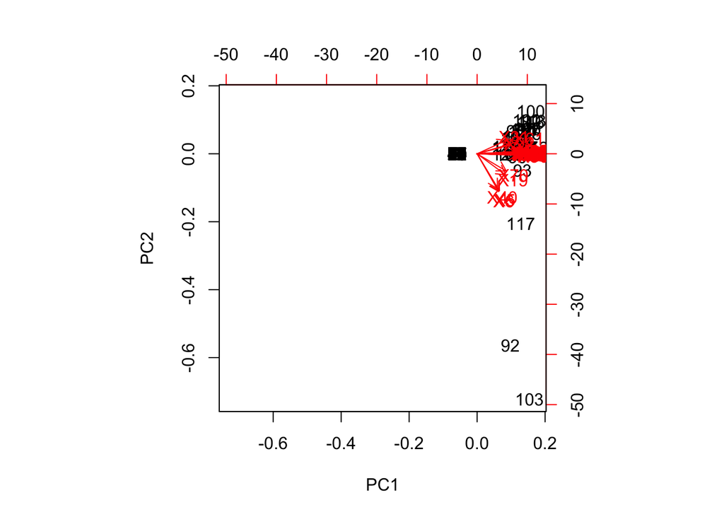

```r
biplot(pca.eye)
```

```r
rots <- pca.eye$rotation
dim(rots)
```

```
## [1] 100 100
```

```r
eye.mat <- as.matrix(eye.df_noresp[,1:ncol(eye.df_noresp)])
dim(eye.mat)
```

```
## [1] 129 100
```

```r
pcs <- eye.mat %*% rots
dim(pcs)
```

```
## [1] 129 100
```

```r
prcomp.df <- data.frame(pcs, resp = type)
```

LASSO on 100 predictors

```r
x <- data.matrix(eye.df[,-ncol(eye.df)])
y <- data.matrix(eye.df[,ncol(eye.df)])
test <- sample(1:nr, nr/2, rep=F)
train <- setdiff(1:nr, test)
x.train <- x[train,]
y.train <- y[train,]
x.test <- x[test,]
y.test <- y[test,]

cv.lasso <- cv.glmnet(x.train, y.train, alpha = 1, family="binomial")
cv.lasso$lambda.min
```

```
## [1] 0.00467802
```

```r
fit.lasso <- glmnet(x.train, y.train, alpha = 1, lambda = cv.lasso$lambda.min, family = "binomial")
coef(fit.lasso)
```

```
## 101 x 1 sparse Matrix of class "dgCMatrix"
##                        s0
## (Intercept)    5.94622241
## X1           -14.64557780
## X2           -40.79578386
## X3             .
## X4             .
## X5             .
## X6             .
## X7             .
## X8          -128.73513723
## X9             .
## X10          -15.42256834
## X11            .
## X12            .
## X13            .
## X14            .
## X15            .
## X16            .
## X17            .
## X18            .
## X19            .
## X20            .
## X21           -0.02840382
## X22            .
## X23            .
## X24            .
## X25            .
## X26            .
## X27            .
## X28            .
## X29            .
## X30          -14.11621455
## X31            .
## X32            .
## X33            .
## X34            .
## X35            .
## X36            .
## X37            .
```

[output cut: 48 more lines]

```
## X86            .
## X87            .
## X88            .
## X89            .
## X90            .
## X91          -12.54802824
## X92            .
## X93           -8.30557296
## X94            .
## X95            .
## X96            .
## X97            .
## X98          -11.37080273
## X99          -23.25395295
## X100         -17.40963841
```

```r
pred.lasso <- predict(fit.lasso, newx = x.test, type="class")
print(as.numeric(pred.lasso))
```

```
##  [1] 0 0 0 1 1 0 1 1 1 1 1 0 0 1 1 0 0 1 0 1 0 1 0 0 1 1 1 0 1 1 1 0 0 1 0
## [36] 1 1 1 0 1 1 1 0 1 1 0 1 1 1 1 1 1 1 1 1 0 1 1 0 1 1 1 1 0
```

```r
print(y.test)
```

```
##  [1] 0 0 0 1 1 0 1 1 1 1 1 0 0 1 1 0 0 1 0 1 0 1 0 0 1 1 1 0 1 1 1 0 0 1 0
## [36] 1 1 1 0 1 1 1 0 1 1 0 1 1 1 1 1 1 1 1 1 0 1 1 0 1 1 1 1 0
```

```r
mean(as.numeric(pred.lasso) != y.test)
```

```
## [1] 0
```